# Choosing priors in Bayesian ecological models by visualization

Jeff Wesner

11/20/2020

# Introduction

The distinguishing feature between Bayesian and non-Bayesian statistics is that Bayesian statistics treats unknown parameters as random variables governed by a probability distribution, while non-Bayesian statistics treats unknown parameters as fixed (Ellison 2004; Hobbs and Hooten 2015). A common misconception is that only Bayesian statistics incorporates prior information. However, non-Bayesian methods can and often do incorporate prior information, either informally in the choices of likelihoods and model structures, or formally as penalized likelihood or hierarchical modeling (Hobbs and Hooten 2015; Morris et al. 2015).

While prior information is not unique to Bayesian models, it is required of them. For example, in a simple linear regression of the form $y ~ N(\alpha + \beta x, \sigma)$ intercept $\alpha$, slope $\beta$, and error $\sigma$ are unknown parameters that need a prior probability distribution. There are differing opinions and philosophies on the best practices for choosing priors (Edwards et al. 1963; Lindley 1971; Morris et al. 2015; Gelman et al. 2017; Wolf et al. 2017; Lemoine 2019; Banner et al. 2020). In ecology, a common practice is to assign so-called non-informative priors that allow Bayesian inference to proceed (i.e. produce a posterior distribution), but with limited influence of the priors (Lemoine 2019). The reasons for this approach are varied but are at least in part driven by a desire to avoid the appearance of subjectivity and/or a reliance on default priors in popular software (Gelman and Hennig 2017; Banner et al. 2020).

Regardless of the philosophy for choosing priors, it is important to understand what the priors actually encode in the model (Gabry et al. 2019; Kennedy et al. 2020). Even for seemingly simple and routine models, like logistic regression, it can be difficult to understand *a priori* how priors affect the model, because they must be assigned in the context of likelihood (Gelman et al. 2017). The result is that prior selection takes place on parameters that are often less intuitive to understand than the ultimate target of the analysis, such as the expected mean or raw $y$ data (Kadane et al. 1980; Bedrick, Christensen, and Johnson 1996; James, Choy, and Mengersen 2010). In other words, ecologists that are interested in understanding the proportion of individuals that are infected with a virus (i.e., the outcome variable), need to assign priors on parameters that operate on the logit-scale (in binomial regression) that is several steps removed from the measure of interest. This potentially leads to unintended mistakes in which a seemingly non-informative prior at the level of the individual parameter becomes informative on the outcome scale (Northrup and Gerber 2018; Gabry et al. 2019; Banner 2020). While this type of mistake might be obvious to an experienced statistician with domain knowledge of the problem at hand, it is quite difficult to conceptualize for the rest of us (Kadane et al. 1980; Bedrick, Christensen, and Johnson 1996). This is particularly true for the types of models that are commonly used in ecology, such as generalized linear mixed models or interaction models, which may have dozens of parameters, each of which require a prior probability distribution (Bedrick, Christensen, and Johnson 1996; McElreath 2020).

We suggest that ecologists can address this problem using simulation from the prior predictive distribution and visualizing the implications of the priors on either the expected mean of the data (e.g., simulate regression lines or group means) (Kadane et al. 1980; Bedrick, Christensen, and Johnson 1996) or by simulating individual data points (Gabry et al. 2019). In this paper, we demonstrate how to use the prior predictive distribution to assign priors using two case studies with ecological data.

# Prior Predictive Simulation

An attractive feature of the Bayesian approach is that the models are generative. This means that we can simulate potential data from the model so long as the parameters are assigned a proper probability distribution (Gelman et al. 2017). This feature is routinely used to check models after fitting the data using the posterior predictive distribution (Gelman et al. 2014), but it can also be used before seeing the data using the prior predictive distribution (Gabry et al. 2019). A simple model from a normal linear regression, using the syntax of (McElreath 2020), is:

$$y^{sims}_i \sim N(\mu^{sims}_i, \sigma^{sims})$$

$$\mu^{sims}_i = \alpha^{sims} + \beta^{sims} x_i$$
$$\alpha^{sims} \sim N(0,1)$$
$$\beta^{sims} \sim N(0,1)$$
$$\sigma^{sims} \sim Exponential(1)$$
where $y^{sims}$ are predicted values of the response variable, $\mu^{sims}$ are simulated values of the expected mean of the outcome, and $\sigma^{sims}$ are simulated errors as standard deviations. Simulations are made across each $i$ value of the predictor variable $x$. In this example, we assumed that $x$ was known (e.g., if it were a gradient of planned Se additions to water before the experiment was conducted or a set of fixed treatments), but it could also be simulated.

With this general model, we do the following:

1. Draw N values from the prior distributions.
2. For each draw, solve the equation for each $i$ value of x
3. Plot the result for either $\mu^{sims}_i$ or $y^{sims}_i$.
4. Use our domain knowledge (or another expert’s) to assess whether the simulated values reflect prior knowledge.
5. If values do not reflect prior knowledge, change the prior distribution, likelihood, or both and repeat the simulation from step 1.
6. If values do reflect prior knowledge,add the data and estimate the posterior distribution.

This amounts to a prior predictive check to satisfy the expectation that “simulations from the full Bayesian model…should be plausible data sets” (Kennedy, Simpson, and Gelman 2019). The simulation and visualization steps (1-3) are critical here, simulated data sets are derived from the *joint distribution* of parameters. In other words, whether data sets are plausible cannot be determined simply from the individual priors or model formula, because they depend on the units of measurement (e.g., a N(0,1) prior means different things if y is measure in $\mu m$ versus km) and on the range of prior expected values. We demonstrate this below with two motivating examples.

# Motivating Examples

## Predator-Prey Body Sizes - Simple Linear Regression

Understanding predator-prey interactions has long been a research interest of ecologists. Body size is related to a number of aspects which influences these interactions. For example, predators are often gape-limited, meaning that larger predators should be able to consume larger prey.

*Data*

The data set of Brose et al. (2006) documents over 10,000 predator-prey interactions, including the mean mass of each. This data set will be used to demonstrate the concept of prior predictive simulations. For this example, we will be using the `rethinking` package.

*Model*

For this example, we examine the hypothesis that the mean prey body mass increases log-linearly with predator body mass using a simple linear model:

$$\begin{equation}
logy_i \sim N(\mu_i, \sigma)
\end{equation}$$

$$ \alpha \sim Normal(0, 100000) $$ $$ \beta \sim Normal(0, 100000) $$ $$ \sigma \sim Exponential(1) $$

First, let’s load the data:

This data table has been cleaned and only includes rows where mean mass for both the predator and prey was recorded.

To simplify this example, we will be working with log-transformed variables:

## Prior Information

Before looking at the data, let’s consider what we *expect* to see. First, let’s consider the intercept. Remember that we are working with data on the log scale. With that in mind, the intercept in this model tells us what the average prey mass is for a predator with mass of 0 on the log scale, which equates to a mass of 1:

```
## [1] 1
```

For a starting point, let’s assume that predators are essentially the same size as their prey. That would mean that the intercept variable, would be centered near 0 on the log-log scale. We will return to the intercept variable for a consideration of the standard deviation of the distribution.

Now that we have an idea of where the intercept should be centered, let’s consider the relationship between prey mass and predator mass. Continuing with the basic assumption that prey are approximately the same size as their predators, an expected slope value of 1 seems reasonable. In other words, the average prey body size increases exactly directly in response to predator mass.

# Flat Priors

First, let’s consider flat priors (sometimes called vague priors). Flat priors are commonly used in the literature, and are often justified because they have little influence on the posterior distributions. Priors are “flattened” by giving them a large standard deviation. An example of a flat prior for a normal distribution would be Normal(0, 10) or even Normal(0,100).

For both the intercept variable, let’s consider a flat prior with a standard deviation of 10. Therefore, our prior distributions are Normal(0, 10) and Normal(1, 10)

In order to assess these priors, let’s simulate some data

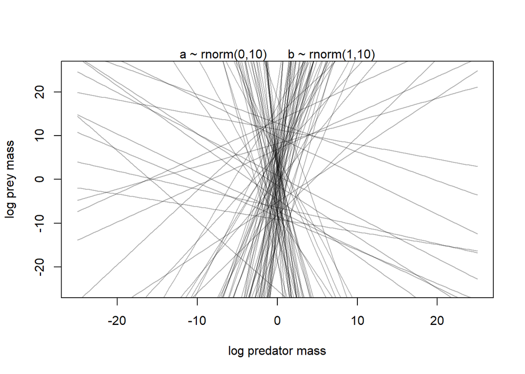

Remember that this is on a log-log scale. In order to put the overall range into perspective, let’s add reference lines for the weight of a virus and a blue whale. On the log scale this is approximately -20.7 and 18.8, respectively.

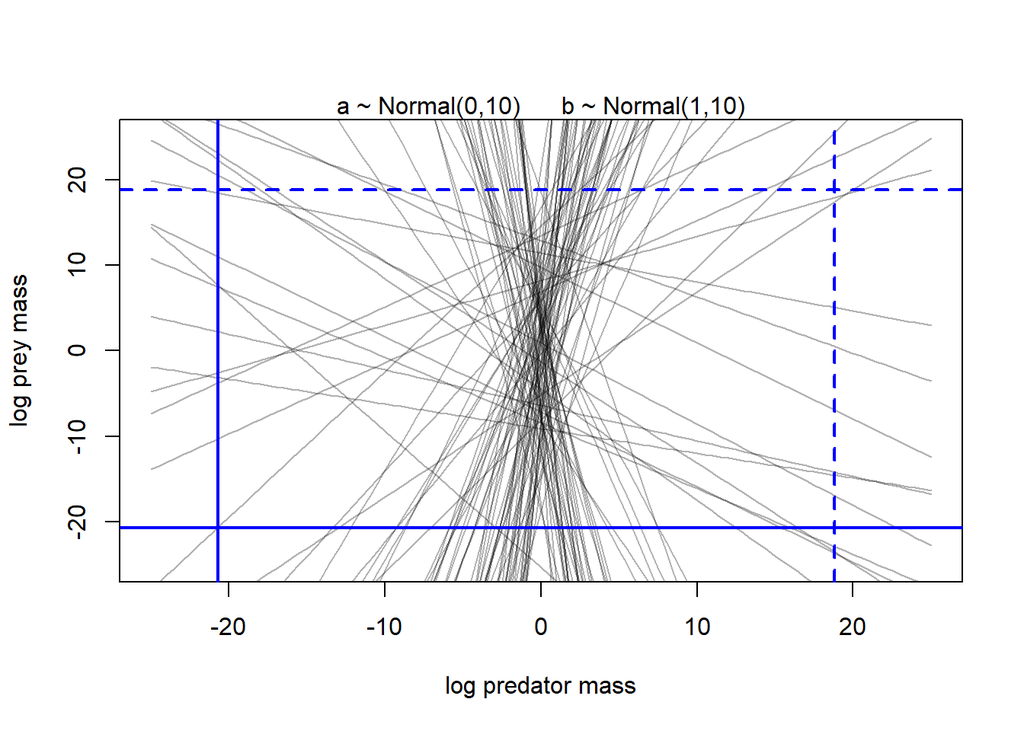

Now, the solid lines indicate the weight of a typical virus, and the dashed lines represent the weight of a blue whale.

For reference, let’s add a 1:1 line to the plot. The 1:1 line is what we would expect to see if the mean prey mass was exactly equal to the predator mass.

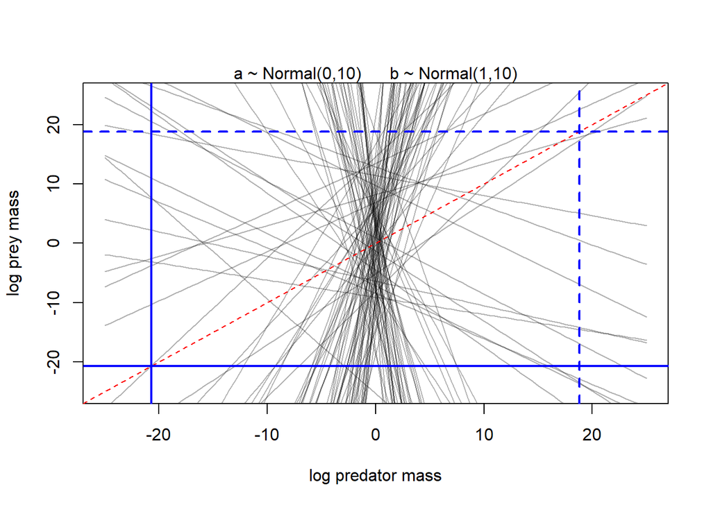

Now, let’s consider the intercept value. we used a prior with a normal distribution with a mean of 0 and an SD of 10. Let’s plot this to visualize what this implies.

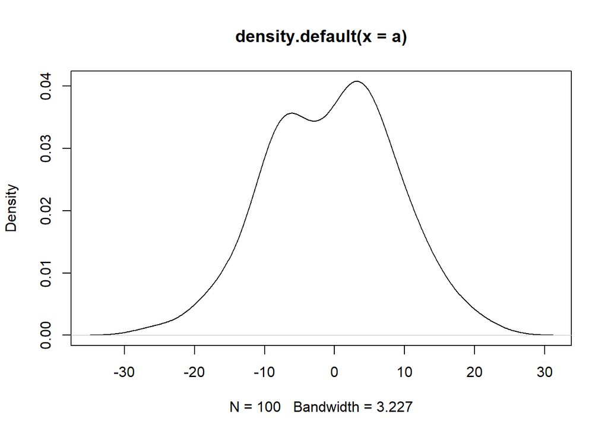

With the large SD value, the model is considering intercepts from -20 to 20 as reasonable. An intercept of -20 essentially means that the mean prey size for a 1 gram predator is approximately the size of a virus. Likewise, an intercept of +20 means that the mean prey size for the same 1 g predator is larger than a blue whale. We can surely limit this to do better, but first, let’s reconsider the mean value.

# Informative priors

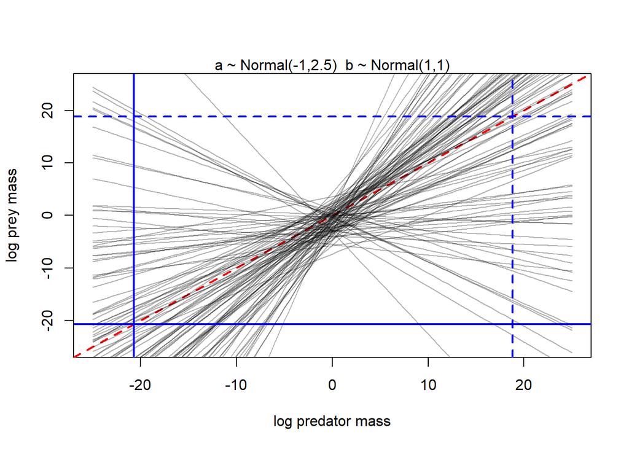

This is certainly looking more reasonable. Most of the intercepts are below the 1:1 line, but there are still quite a few above it, meaning that the model will be testing a range of values, and the priors won’t be overwhelming the data.

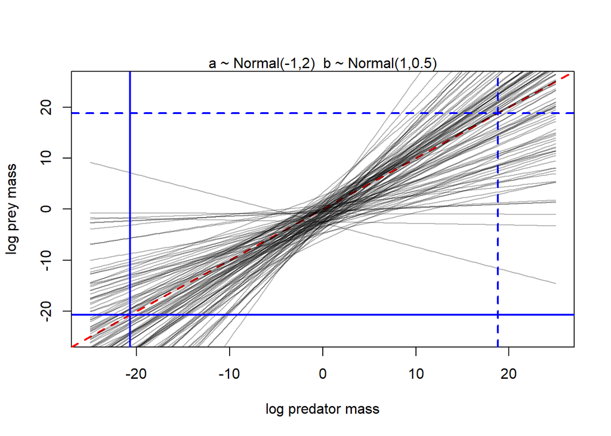

Now let’s fit a model, just to illustrate what we actually find.

|  | mean | sd | 5.5% | 94.5% |
| --- | --- | --- | --- | --- |
| a | -4.7976349 | 0.050388151 | -4.8781649 | -4.7171049 |
| b | 0.5985905 | 0.007285022 | 0.5869476 | 0.6102334 |
| sigma | 3.6593707 | 0.022615828 | 3.6232263 | 3.6955152 |

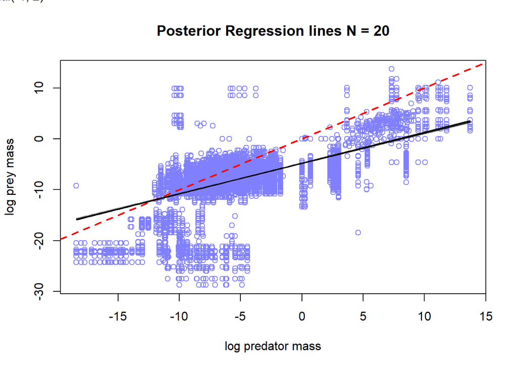

# Discussion

Prior predictive simulation is not new, but the ability to do it and visualize the outcome is now far easier than in the past.

#### Deleted Text

Bayesian statistics combines a likelihood $p(y|\theta)$, which describes the probability of data given a parameter value, with a prior distribution $p(\theta)$, which reflects the prior probability of the parameter before seeing the data. Multiplying these and then dividing by the marginal distribution of the data $\int p(y|\theta)p(\theta)d\theta$ (or using numerical techniques like Markov Chain Monte Carlo), gives a posterior probability of model parameters $p(\theta|y)$, or joint posterior probability (Hobbs and Hooten 2015). We can use this joint posterior to make inference about specific hypotheses. The hypotheses might relate to individual model parameters, such as the probability that a slope is greater than zero in a linear regression, or to derived quantities, such as the probability that one group has a higher mean value than another group (Hobbs and Hooten 2015; Korner-Nievergelt et al. 2015).

Bedrick, Edward J, Ronald Christensen, and Wesley Johnson. 1996. “A New Perspective on Priors for Generalized Linear Models.” *Journal of the American Statistical Association* 91 (436): 1450–60.

Gabry, Jonah, Daniel Simpson, Aki Vehtari, Michael Betancourt, and Andrew Gelman. 2019. “Visualization in Bayesian Workflow.” *Journal of the Royal Statistical Society: Series A (Statistics in Society)* 182 (2): 389–402. https://doi.org/10.1111/rssa.12378.

Hobbs, N Thompson, and Mevin B Hooten. 2015. *Bayesian Models: A Statistical Primer for Ecologists*. Princeton University Press.

James, Allan, Samantha Low Choy, and Kerrie Mengersen. 2010. “Elicitator: An Expert Elicitation Tool for Regression in Ecology.” *Environmental Modelling & Software* 25 (1): 129–45.

Kadane, Joseph B, James M Dickey, Robert L Winkler, Wayne S Smith, and Stephen C Peters. 1980. “Interactive Elicitation of Opinion for a Normal Linear Model.” *Journal of the American Statistical Association* 75 (372): 845–54.

Kennedy, Lauren, Daniel Simpson, and Andrew Gelman. 2019. “The Experiment Is Just as Important as the Likelihood in Understanding the Prior: A Cautionary Note on Robust Cognitive Modeling.” *Computational Brain & Behavior* 2 (3-4): 210–17.

Korner-Nievergelt, Franzi, Tobias Roth, Stefanie Von Felten, Jérôme Guélat, Bettina Almasi, and Pius Korner-Nievergelt. 2015. *Bayesian Data Analysis in Ecology Using Linear Models with R, BUGS, and Stan*. Academic Press.

McElreath, Richard. 2020. *Statistical Rethinking: A Bayesian Course with Examples in R and Stan*. CRC press.